# Week 7 Demo

Katz

3/02/2021

# Week 7 - logistic regression

To study how to run a logistic regression model in R, we are going to create simulate some data.

NOTE: Simulating data is a good way to get a sense of how the model works since you already know the data-generate process that you are trying to characterize with the model. This means you already know the “ground truth”. In practice, we do not have this luxury when we run our studies - it is this “ground truth” that we’re looking for. Nonetheless, it can be helpful to remove one piece of uncertainty when learning the technical aspects by using data that are already characterized because you made them.

We will proceed through several rounds of data generation to see how the model may vary.

### Round 1 - no systematic variation in outcomes

```r
disciplines <- c("civil", "mechanical", "electrical", "systems")
disciplines_prob <- c(0.25, 0.3, 0.35, 0.1)


know_engineer <- c("immediate_fam", "distant_fam", "friend", "none")
know_engineer_prob <- c(0.2, 0.4, 0.3, 0.1)


persistence <- c("yes", "no")
persistence_prob <- c(0.8, 0.2)
```

Now we will generate the actual sample of 500 students

```r
samp_size <- 500

disc_samp <- sample(x = disciplines, size = samp_size, prob = disciplines_prob, replace = TRUE)
know_samp <- sample(x = know_engineer, size = samp_size, prob = know_engineer_prob, replace = TRUE)
pers_samp <- sample(x = persistence, size = samp_size, prob = persistence_prob, replace = TRUE)


samp_df <- tibble(discipline = disc_samp,
                  know_eng = know_samp,
                  persist = pers_samp,
                  gpa = round(rnorm(n = samp_size, mean = 3, sd = 0.3), 2))
```

Up to now, we have simulated the data collection process. This is the point where we would typically be cleaning the data and starting our analysis

First, add in a new binary column for the persistence variable (coding “yes” as 1 and “no” as 0)

```r
samp_df <- samp_df %>%
  mutate(persist_bin = case_when(persist == "yes" ~ 1,
                                 persist == "no" ~ 0))
```

Second, get a sense of the distributions of some of the variables in our model

```r
str(samp_df)
```

```
## tibble [500 x 5] (S3: tbl_df/tbl/data.frame)
##  $ discipline : chr [1:500] "electrical" "civil" "civil" "civil" ...
##  $ know_eng   : chr [1:500] "friend" "distant_fam" "distant_fam" "distant_fam" ...
##  $ persist    : chr [1:500] "yes" "no" "yes" "yes" ...
##  $ gpa        : num [1:500] 3.1 3.06 3.22 3.02 2.83 2.52 2.64 3.3 2.87 3.21 ...
##  $ persist_bin: num [1:500] 1 0 1 1 1 0 0 1 1 1 ...
```

```r
table(samp_df$persist)
```

```
##
##  no yes
## 100 400
```

```r
describe(samp_df)
```

```
##             vars   n mean   sd median trimmed  mad  min  max range  skew
## discipline*    1 500  NaN   NA     NA     NaN   NA  Inf -Inf  -Inf    NA
## know_eng*      2 500  NaN   NA     NA     NaN   NA  Inf -Inf  -Inf    NA
## persist*       3 500  NaN   NA     NA     NaN   NA  Inf -Inf  -Inf    NA
## gpa            4 500 3.01 0.32   3.01    3.02 0.33 2.13  3.8  1.67 -0.14
## persist_bin    5 500 0.80 0.40   1.00    0.88 0.00 0.00  1.0  1.00 -1.50
##             kurtosis   se
## discipline*       NA   NA
## know_eng*         NA   NA
## persist*          NA   NA
## gpa            -0.33 0.01
## persist_bin     0.24 0.02
```

```r
table(samp_df$discipline)
```

```
##
##      civil electrical mechanical    systems
##        112        170        157         61
```

```r
xtabs(~ discipline + persist_bin, data = samp_df)
```

```
##             persist_bin
## discipline     0   1
##   civil       25  87
##   electrical  32 138
##   mechanical  30 127
##   systems     13  48
```

Third, model the outcome (persistence) as a function of three predictor variables (discipline, knowing an engineering, and gpa)

```r
model <- glm(persist_bin ~ discipline + know_eng + gpa, data = samp_df, family = binomial())
summary(model)
```

```
##
## Call:
## glm(formula = persist_bin ~ discipline + know_eng + gpa, family = binomial(),
##     data = samp_df)
##
## Deviance Residuals:
##     Min       1Q   Median       3Q      Max
## -1.9674   0.5640   0.6658   0.6851   0.7430
##
## Coefficients:
##                       Estimate Std. Error z value Pr(>|z|)
## (Intercept)            1.27461    1.13065   1.127    0.260
## disciplineelectrical   0.18085    0.30153   0.600    0.549
## disciplinemechanical   0.17781    0.30643   0.580    0.562
## disciplinesystems      0.06042    0.38804   0.156    0.876
## know_engfriend         0.05050    0.26108   0.193    0.847
## know_engimmediate_fam  0.41525    0.33040   1.257    0.209
## know_engnone           0.13276    0.43029   0.309    0.758
## gpa                   -0.03708    0.36137  -0.103    0.918
##
## (Dispersion parameter for binomial family taken to be 1)
##
##     Null deviance: 500.40  on 499  degrees of freedom
## Residual deviance: 498.01  on 492  degrees of freedom
## AIC: 514.01
##
## Number of Fisher Scoring iterations: 4
```

```r
tidy(model)
```

```
## # A tibble: 8 x 5
##   term                  estimate std.error statistic p.value
##   <chr>                    <dbl>     <dbl>     <dbl>   <dbl>
## 1 (Intercept)             1.27       1.13      1.13    0.260
## 2 disciplineelectrical    0.181      0.302     0.600   0.549
## 3 disciplinemechanical    0.178      0.306     0.580   0.562
## 4 disciplinesystems       0.0604     0.388     0.156   0.876
## 5 know_engfriend          0.0505     0.261     0.193   0.847
## 6 know_engimmediate_fam   0.415      0.330     1.26    0.209
## 7 know_engnone            0.133      0.430     0.309   0.758
## 8 gpa                    -0.0371     0.361    -0.103   0.918
```

Since we generated the data without any relationships between the predictors and the binary outcome, we do not expect any of the predictor variables to be statistically significant. Sometimes there will be a significant predictor, but that emphasizes the idea p values are not necessarily the most reliable indicator of importance.

### Round 2 - systematic varation in outcomes as a function of discipline

Now, to introduce some systematic variation, we will change the probabilities of persistence (the outcome variable we are modeling) as a function of major but not as a function of the other two predictors

```r
disciplines <- c("civil", "mechanical", "electrical", "systems")
disciplines_prob <- c(0.25, 0.3, 0.35, 0.1)


know_engineer <- c("immediate_fam", "distant_fam", "friend", "none")
know_engineer_prob <- c(0.2, 0.4, 0.3, 0.1)
```

We generate the actual data here.

```r
samp_size <- 5000

disc_samp_2 <- sample(x = disciplines, size = samp_size, prob = disciplines_prob, replace = TRUE)
know_samp_2 <- sample(x = know_engineer, size = samp_size, prob = know_engineer_prob, replace = TRUE)
#pers_samp_2 <- sample(x = persistence, size = samp_size, prob = persistence_prob, replace = TRUE)
```

Now we will combine our data into one dataframe.

```r
samp_df_2 <- tibble(discipline = disc_samp_2,
                  know_eng = know_samp_2,
                  gpa = round(rnorm(n = samp_size, mean = 3, sd = 0.3), 2))
```

Now we want to have some different outcomes whose probabilities vary by discipline. We’ll create a new column called persist_prob that describes the probability of persisting from year one to year two (e.g., 0.6 means there is a 0.6 prob of a student persisting)

```r
samp_df_2 <- samp_df_2 %>%
  mutate(persist_prob = case_when(discipline == "civil" ~ 0.6,
                             discipline == "mechanical" ~ 0.7,
                             discipline == "electrical" ~ 0.8,
                             discipline == "systems" ~ 0.9))
```

We will create a vector that samples depending on the value of the persistence probability at that index. That value varies depending on the discipline for that student at that index value in the vector.

```r
persist_outcome <- modify(.x = samp_df_2$persist_prob, .f = ~rbinom(n = 1, size = 1, prob = .x))
```

Now we add that persistence outcome column to our dataframe

```r
samp_df_2$persist_bin <- persist_outcome
```

Up to now, we have simulated the data collection process. This is the point where we would typically be cleaning the data and starting our analysis,

```r
str(samp_df_2)
```

```
## tibble [5,000 x 5] (S3: tbl_df/tbl/data.frame)
##  $ discipline  : chr [1:5000] "systems" "mechanical" "mechanical" "systems" ...
##  $ know_eng    : chr [1:5000] "friend" "immediate_fam" "friend" "friend" ...
##  $ gpa         : num [1:5000] 3.35 3.35 3.29 2.97 2.87 2.63 2.68 3.2 2.84 2.48 ...
##  $ persist_prob: num [1:5000] 0.9 0.7 0.7 0.9 0.8 0.7 0.9 0.6 0.8 0.8 ...
##  $ persist_bin : num [1:5000] 1 1 1 1 1 1 1 0 1 1 ...
```

Let’s check on the distribution of persistence by major. xtabs() is a function that creates a contingency table (more on that in 2 weeks)

```r
xtabs(~ persist_bin + discipline, data=samp_df_2)
```

```
##            discipline
## persist_bin civil electrical mechanical systems
##           0   499        359        451      54
##           1   728       1410       1062     437
```

Or we can use `describe()`

```r
describe(samp_df_2)
```

```
##              vars    n mean   sd median trimmed  mad  min  max range  skew
## discipline*     1 5000  NaN   NA     NA     NaN   NA  Inf -Inf  -Inf    NA
## know_eng*       2 5000  NaN   NA     NA     NaN   NA  Inf -Inf  -Inf    NA
## gpa             3 5000 3.00 0.30    3.0    3.00 0.30 1.86 4.11  2.25  0.01
## persist_prob    4 5000 0.73 0.09    0.7    0.73 0.15 0.60 0.90  0.30  0.05
## persist_bin     5 5000 0.73 0.45    1.0    0.78 0.00 0.00 1.00  1.00 -1.02
##              kurtosis   se
## discipline*        NA   NA
## know_eng*          NA   NA
## gpa              0.01 0.00
## persist_prob    -1.01 0.00
## persist_bin     -0.96 0.01
```

Or even use `table()`

```r
table(samp_df_2$discipline)
```

```
##
##      civil electrical mechanical    systems
##       1227       1769       1513        491
```

Now, model the outcome (persistence) as a function of three predictor variables (discipline, knowing an engineering, and gpa)

```r
model_2 <- glm(persist_bin ~ discipline + know_eng + gpa, data = samp_df_2, family = binomial())
```

And examine the model output with either `summary()`…

```r
summary(model_2)
```

```
##
## Call:
## glm(formula = persist_bin ~ discipline + know_eng + gpa, family = binomial(),
##     data = samp_df_2)
##
## Deviance Residuals:
##     Min       1Q   Median       3Q      Max
## -2.1629  -1.3101   0.6735   0.8417   1.0630
##
## Coefficients:
##                       Estimate Std. Error z value Pr(>|z|)
## (Intercept)            0.39402    0.33240   1.185   0.2359
## disciplineelectrical   0.98847    0.08298  11.912  < 2e-16 ***
## disciplinemechanical   0.47637    0.08092   5.887 3.93e-09 ***
## disciplinesystems      1.71615    0.15558  11.030  < 2e-16 ***
## know_engfriend         0.07753    0.07752   1.000   0.3173
## know_engimmediate_fam  0.21009    0.09056   2.320   0.0203 *
## know_engnone           0.09472    0.11730   0.808   0.4194
## gpa                   -0.02984    0.10843  -0.275   0.7832
## ---
## Signif. codes:  0 '***' 0.001 '**' 0.01 '*' 0.05 '.' 0.1 ' ' 1
##
## (Dispersion parameter for binomial family taken to be 1)
##
##     Null deviance: 5858.3  on 4999  degrees of freedom
## Residual deviance: 5620.9  on 4992  degrees of freedom
## AIC: 5636.9
##
## Number of Fisher Scoring iterations: 4
```

…or `tidy()`

```r
tidy(model_2)
```

```
## # A tibble: 8 x 5
##   term                  estimate std.error statistic  p.value
##   <chr>                    <dbl>     <dbl>     <dbl>    <dbl>
## 1 (Intercept)             0.394     0.332      1.19  2.36e- 1
## 2 disciplineelectrical    0.988     0.0830    11.9   1.03e-32
## 3 disciplinemechanical    0.476     0.0809     5.89  3.93e- 9
## 4 disciplinesystems       1.72      0.156     11.0   2.73e-28
## 5 know_engfriend          0.0775    0.0775     1.00  3.17e- 1
## 6 know_engimmediate_fam   0.210     0.0906     2.32  2.03e- 2
## 7 know_engnone            0.0947    0.117      0.808 4.19e- 1
## 8 gpa                    -0.0298    0.108     -0.275 7.83e- 1
```

```r
disciplines <- c("civil", "mechanical", "electrical", "systems")
disciplines_prob <- c(0.25, 0.3, 0.35, 0.1)

know_engineer <- c("immediate_fam", "distant_fam", "friend", "none")
know_engineer_prob <- c(0.2, 0.4, 0.3, 0.1)
```

Simulate the dataf or disciplines, knowing an engineer, and the persistence outcome

```r
samp_size <- 500

disc_samp_3 <- sample(x = disciplines, size = samp_size, prob = disciplines_prob, replace = TRUE)
know_samp_3 <- sample(x = know_engineer, size = samp_size, prob = know_engineer_prob, replace = TRUE)
pers_samp_3 <- sample(x = persistence, size = samp_size, prob = persistence_prob, replace = TRUE)
```

And combine all the generated data into one dataframe with `tibble()`.

```r
samp_df_3 <- tibble(discipline = disc_samp_3,
                  know_eng = know_samp_3,
                  persist = pers_samp_3)
```

Up to now, we have simulated the data collection process. This is the point where we would typically be cleaning the data and starting out analysis

To run the logistic regression, we need our outcome coded as 0/1, not no/yes to address this, we add in a new binary column for the persistence variable (coding “yes” as 1 and “no” as 0)

```r
samp_df_3 <- samp_df_3 %>%
  mutate(persist_bin = case_when(persist == "yes" ~ 1,
                                 persist == "no" ~ 0))
```

Now, since we want to look at the potential effect of gpa on persistence, we create a bookkeeping column for gpa_mean for students who do and do not persist to year two.

```r
samp_df_3 <- samp_df_3 %>%
  mutate(gpa_mean = case_when(persist == "yes" ~ 3.4,
                              persist == "no" ~ 3.0))
```

Simulate the gpa data

```r
gpa_vec <- round(modify(.x = samp_df_3$gpa_mean, .f = ~rnorm(n = 1, mean = .x, sd = .2)), 2)
```

Add the simulated data back to our data frame

```r
samp_df_3$gpa <- gpa_vec
```

Up to now, we have simulated the data collection process. This is the point where we would typically be cleaning the data and starting our analysis

Check the structure of the dataframe to make sure it looks as expected

```r
str(samp_df_3)
```

```
## tibble [500 x 6] (S3: tbl_df/tbl/data.frame)
##  $ discipline : chr [1:500] "systems" "electrical" "electrical" "electrical" ...
##  $ know_eng   : chr [1:500] "immediate_fam" "none" "distant_fam" "none" ...
##  $ persist    : chr [1:500] "yes" "yes" "yes" "yes" ...
##  $ persist_bin: num [1:500] 1 1 1 1 1 1 1 0 0 1 ...
##  $ gpa_mean   : num [1:500] 3.4 3.4 3.4 3.4 3.4 3.4 3.4 3 3 3.4 ...
##  $ gpa        : num [1:500] 3.47 3.75 3.31 3.48 3.62 3.28 3.42 2.79 3.08 3.21 ...
```

Let’s check on the distribution of persistence by major. xtabs() is a function that creates a contingency table (more on that in 2 weeks)

```r
xtabs(~ persist_bin + discipline, data=samp_df_3)
```

```
##            discipline
## persist_bin civil electrical mechanical systems
##           0    25         37         38       9
##           1    93        140        119      39
```

…or with `describe()`…

```r
describe(samp_df_3)
```

```
##             vars   n mean   sd median trimmed  mad  min  max range  skew
## discipline*    1 500  NaN   NA     NA     NaN   NA  Inf -Inf  -Inf    NA
## know_eng*      2 500  NaN   NA     NA     NaN   NA  Inf -Inf  -Inf    NA
## persist*       3 500  NaN   NA     NA     NaN   NA  Inf -Inf  -Inf    NA
## persist_bin    4 500 0.78 0.41   1.00    0.85 0.00 0.00 1.00  1.00 -1.36
## gpa_mean       5 500 3.31 0.17   3.40    3.34 0.00 3.00 3.40  0.40 -1.36
## gpa            6 500 3.30 0.25   3.31    3.31 0.27 2.47 3.94  1.47 -0.35
##             kurtosis   se
## discipline*       NA   NA
## know_eng*         NA   NA
## persist*          NA   NA
## persist_bin    -0.15 0.02
## gpa_mean       -0.15 0.01
## gpa            -0.44 0.01
```

…or with `table()`.

```r
table(samp_df_3$discipline)
```

```
##
##      civil electrical mechanical    systems
##        118        177        157         48
```

Check the distribution of the gpa values by discipline, just to make sure

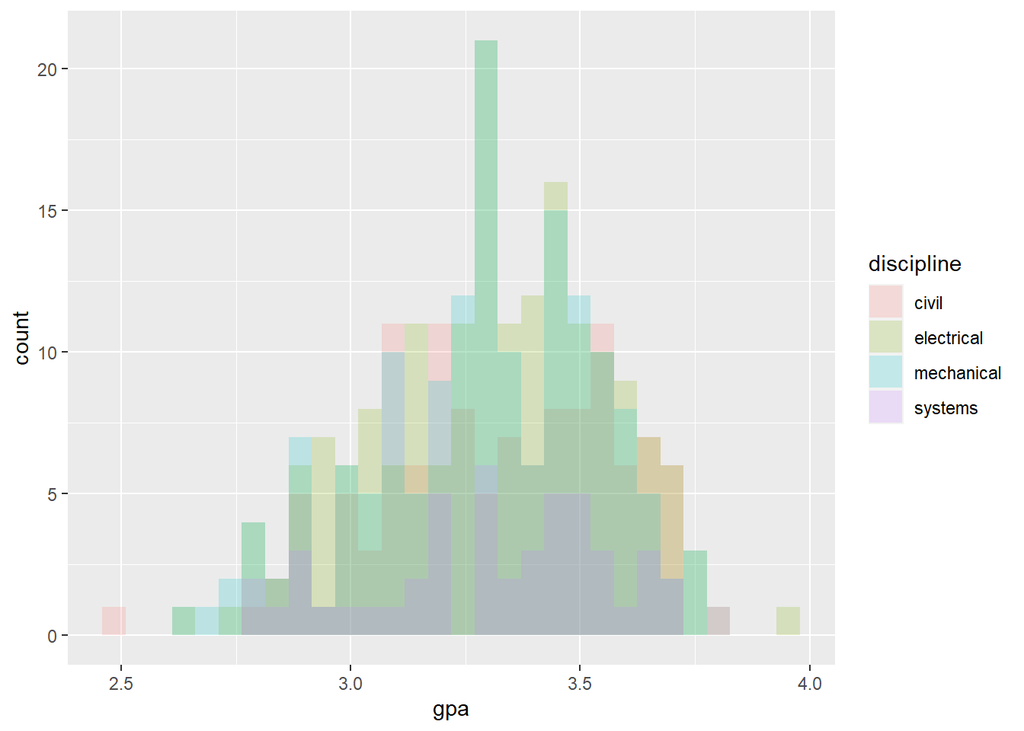

```r
samp_df_3 %>%
  ggplot(aes(x = gpa, fill = discipline)) +
  geom_histogram(alpha = 0.2, position = "identity")
```

```r
# be sure to put alpha before position
```

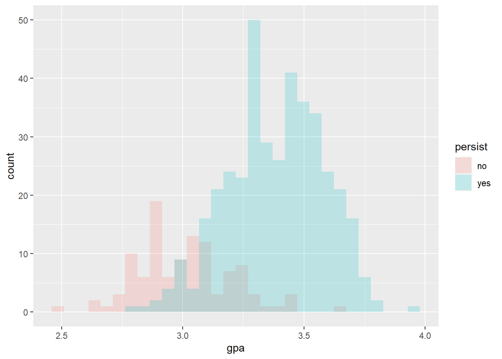

```r
samp_df_3 %>%
  ggplot(aes(x = gpa, fill = persist)) +
  geom_histogram(alpha = 0.2, position = "identity")
```

Now, model the outcome (persistence) as a function of three predictor variables (discipline, knowing an engineering, and gpa)

```r
model_3 <- glm(persist_bin ~ discipline + know_eng + gpa, data = samp_df_3, family = binomial())
```

And examine the results with `summary()` or `tidy()`

```r
summary(model_3)
```

```
##
## Call:
## glm(formula = persist_bin ~ discipline + know_eng + gpa, family = binomial(),
##     data = samp_df_3)
##
## Deviance Residuals:
##     Min       1Q   Median       3Q      Max
## -3.3395   0.0670   0.1984   0.4641   2.3922
##
## Coefficients:
##                       Estimate Std. Error z value Pr(>|z|)
## (Intercept)           -28.4520     2.8741  -9.900   <2e-16 ***
## disciplineelectrical    0.0708     0.3863   0.183    0.855
## disciplinemechanical   -0.1896     0.3906  -0.485    0.627
## disciplinesystems       0.2800     0.6103   0.459    0.646
## know_engfriend          0.3210     0.3645   0.881    0.379
## know_engimmediate_fam   0.1915     0.3941   0.486    0.627
## know_engnone            0.5513     0.5187   1.063    0.288
## gpa                     9.2591     0.9048  10.233   <2e-16 ***
## ---
## Signif. codes:  0 '***' 0.001 '**' 0.01 '*' 0.05 '.' 0.1 ' ' 1
##
## (Dispersion parameter for binomial family taken to be 1)
##
##     Null deviance: 524.36  on 499  degrees of freedom
## Residual deviance: 299.85  on 492  degrees of freedom
## AIC: 315.85
##
## Number of Fisher Scoring iterations: 6
```

```r
tidy(model_3)
```

```
## # A tibble: 8 x 5
##   term                  estimate std.error statistic  p.value
##   <chr>                    <dbl>     <dbl>     <dbl>    <dbl>
## 1 (Intercept)           -28.5        2.87     -9.90  4.18e-23
## 2 disciplineelectrical    0.0708     0.386     0.183 8.55e- 1
## 3 disciplinemechanical   -0.190      0.391    -0.485 6.27e- 1
## 4 disciplinesystems       0.280      0.610     0.459 6.46e- 1
## 5 know_engfriend          0.321      0.365     0.881 3.79e- 1
## 6 know_engimmediate_fam   0.191      0.394     0.486 6.27e- 1
## 7 know_engnone            0.551      0.519     1.06  2.88e- 1
## 8 gpa                     9.26       0.905    10.2   1.41e-24
```

### Round 4 - gpa and persistence vary by discipline

```r
disciplines <- c("civil", "mechanical", "electrical", "systems")
disciplines_prob <- c(0.25, 0.3, 0.35, 0.1)

know_engineer <- c("immediate_fam", "distant_fam", "friend", "none")
know_engineer_prob <- c(0.2, 0.4, 0.3, 0.1)
```

Simulate the data for disciplines, knowing an engineer, and the persistence outcome

```r
samp_size <- 500

student_id <- seq(samp_size)
disc_samp_4 <- sample(x = disciplines, size = samp_size, prob = disciplines_prob, replace = TRUE)
know_samp_4 <- sample(x = know_engineer, size = samp_size, prob = know_engineer_prob, replace = TRUE)
pers_samp_4 <- sample(x = persistence, size = samp_size, prob = persistence_prob, replace = TRUE)
```

Combine these all together in `tibble()`.

```r
samp_df_4 <- tibble(sid = student_id,
                    discipline = disc_samp_4,
                    know_eng = know_samp_4)
```

Up to now, we have simulated the data collection process. This is the point where we would typically be cleaning the data and starting out analysis

#### Start the data analysis for logistic regression here

```r
samp_df_4 <- samp_df_4 %>%
  mutate(gpa_mean = case_when(discipline == "civil" ~ 3.0,
                              discipline == "electrical" ~ 3.15,
                              discipline == "mechanical" ~ 3.3,
                              discipline == "systems" ~ 3.45))
```

Simulate the gpa data.

```r
gpa_vec <- round(modify(.x = samp_df_4$gpa_mean, .f = ~rnorm(n = 1, mean = .x, sd = .1)), 2)
```

Add the simulated data back to our data frame

```r
samp_df_4$gpa <- gpa_vec
```

We will create a vector that samples depending on the value of the persistence probability at that index.

That value varies depending on the discipline for that student at that index value in the vector.

persist_prob that describes the probability of persisting from year one to year two (e.g., 0.6 means there is a 0.6 prob of a student persisting)

```r
samp_df_4 <- samp_df_4 %>%
  mutate(persist_prob = case_when(discipline == "civil" ~ 0.6,
                                  discipline == "mechanical" ~ 0.7,
                                  discipline == "electrical" ~ 0.8,
                                  discipline == "systems" ~ 0.9))
```

```r
persist_outcome <- modify(.x = samp_df_4$persist_prob, .f = ~rbinom(n = 1, size = 1, prob = .x))
```

Now we add that persistence outcome column to our dataframe

```r
samp_df_4$persist_bin <- persist_outcome
```

Up to now, we have simulated the data collection process. This is the point where we would typically be cleaning the data and starting our analysis

Check the structure of the dataframe to make sure it looks as expected.

```r
str(samp_df_4)
```

```
## tibble [500 x 7] (S3: tbl_df/tbl/data.frame)
##  $ sid         : int [1:500] 1 2 3 4 5 6 7 8 9 10 ...
##  $ discipline  : chr [1:500] "civil" "electrical" "civil" "electrical" ...
##  $ know_eng    : chr [1:500] "immediate_fam" "immediate_fam" "distant_fam" "friend" ...
##  $ gpa_mean    : num [1:500] 3 3.15 3 3.15 3.45 3 3.15 3 3 3 ...
##  $ gpa         : num [1:500] 3.06 3.32 3.04 3.13 3.41 3.01 3.02 3.04 3.01 3.06 ...
##  $ persist_prob: num [1:500] 0.6 0.8 0.6 0.8 0.9 0.6 0.8 0.6 0.6 0.6 ...
##  $ persist_bin : num [1:500] 1 1 1 1 1 0 1 0 0 1 ...
```

Let’s check on the distribution of persistence by major. xtabs() is a function that creates a contingency table (more on that in 2 weeks).

```r
xtabs(~ persist_bin + discipline, data=samp_df_4)
```

```
##            discipline
## persist_bin civil electrical mechanical systems
##           0    45         32         54       5
##           1    69        144        109      42
```

```r
describe(samp_df_4)
```

```
##              vars   n   mean     sd median trimmed    mad  min    max  range
## sid             1 500 250.50 144.48 250.50  250.50 185.32 1.00 500.00 499.00
## discipline*     2 500    NaN     NA     NA     NaN     NA  Inf   -Inf   -Inf
## know_eng*       3 500    NaN     NA     NA     NaN     NA  Inf   -Inf   -Inf
## gpa_mean        4 500   3.19   0.14   3.15    3.19   0.22 3.00   3.45   0.45
## gpa             5 500   3.19   0.17   3.19    3.19   0.18 2.66   3.67   1.01
## persist_prob    6 500   0.73   0.09   0.70    0.73   0.15 0.60   0.90   0.30
## persist_bin     7 500   0.73   0.45   1.00    0.78   0.00 0.00   1.00   1.00
##               skew kurtosis   se
## sid           0.00    -1.21 6.46
## discipline*     NA       NA   NA
## know_eng*       NA       NA   NA
## gpa_mean      0.13    -0.89 0.01
## gpa           0.14    -0.34 0.01
## persist_prob  0.05    -0.95 0.00
## persist_bin  -1.02    -0.96 0.02
```

```r
table(samp_df_4$discipline)
```

```
##
##      civil electrical mechanical    systems
##        114        176        163         47
```

Check the distribution of the gpa values by discipline, just to make sure.

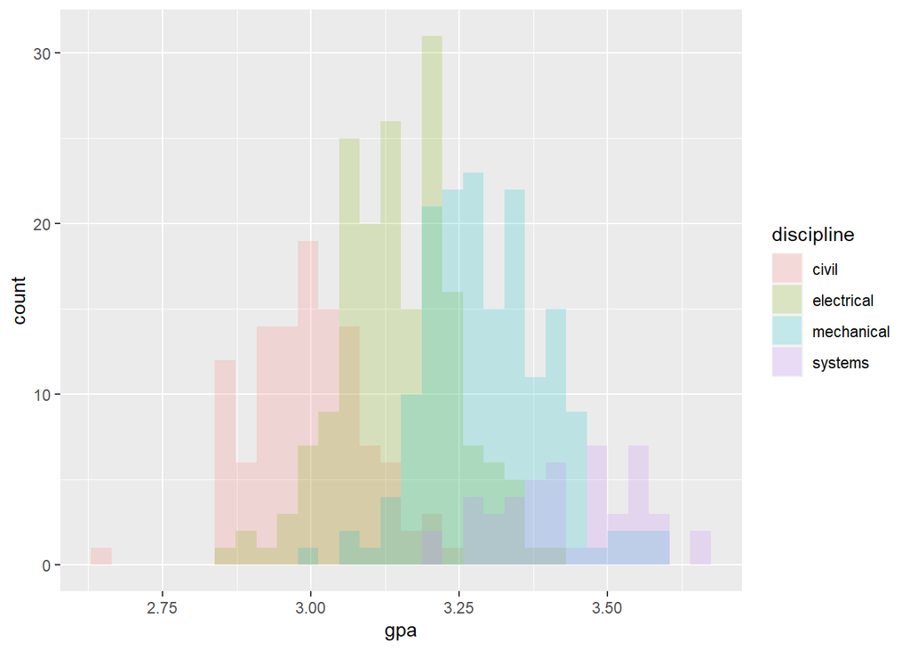

```r
samp_df_4 %>%
  ggplot(aes(x = gpa, fill = discipline)) +
  geom_histogram(alpha = 0.2, position = "identity")
```

- be sure to put alpha before position

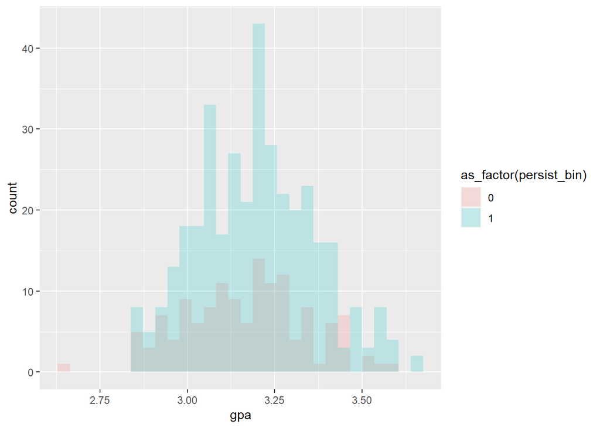

```r
samp_df_4 %>%
  ggplot(aes(x = gpa, fill = as_factor(persist_bin))) +
  geom_histogram(alpha = 0.2, position = "identity")
```

Now, model the outcome (persistence) as a function of three predictor variables (discipline, knowing an engineering, and gpa)

```r
model_4 <- glm(persist_bin ~ discipline + know_eng + gpa, data = samp_df_4, family = binomial())
summary(model_4)
```

```
##
## Call:
## glm(formula = persist_bin ~ discipline + know_eng + gpa, family = binomial(),
##     data = samp_df_4)
##
## Deviance Residuals:
##     Min       1Q   Median       3Q      Max
## -2.3194  -1.3119   0.6486   0.9223   1.0489
##
## Coefficients:
##                        Estimate Std. Error z value Pr(>|z|)
## (Intercept)            0.319495   3.080483   0.104 0.917395
## disciplineelectrical   1.113309   0.316400   3.519 0.000434 ***
## disciplinemechanical   0.296593   0.403937   0.734 0.462793
## disciplinesystems      1.676521   0.687002   2.440 0.014673 *
## know_engfriend         0.028058   0.242118   0.116 0.907742
## know_engimmediate_fam  0.056902   0.280761   0.203 0.839391
## know_engnone           1.195312   0.508736   2.350 0.018795 *
## gpa                   -0.002902   1.025834  -0.003 0.997743
## ---
## Signif. codes:  0 '***' 0.001 '**' 0.01 '*' 0.05 '.' 0.1 ' ' 1
##
## (Dispersion parameter for binomial family taken to be 1)
##
##     Null deviance: 585.24  on 499  degrees of freedom
## Residual deviance: 551.53  on 492  degrees of freedom
## AIC: 567.53
##
## Number of Fisher Scoring iterations: 4
```

```r
tidy(model_4)
```

```
## # A tibble: 8 x 5
##   term                  estimate std.error statistic  p.value
##   <chr>                    <dbl>     <dbl>     <dbl>    <dbl>
## 1 (Intercept)            0.319       3.08    0.104   0.917
## 2 disciplineelectrical   1.11        0.316   3.52    0.000434
## 3 disciplinemechanical   0.297       0.404   0.734   0.463
## 4 disciplinesystems      1.68        0.687   2.44    0.0147
## 5 know_engfriend         0.0281      0.242   0.116   0.908
## 6 know_engimmediate_fam  0.0569      0.281   0.203   0.839
## 7 know_engnone           1.20        0.509   2.35    0.0188
## 8 gpa                   -0.00290     1.03   -0.00283 0.998
```

### Interlude looking at poisson distribution

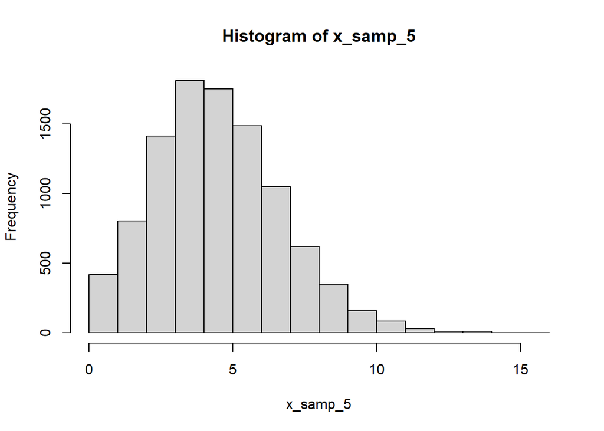

```r
n <- 10000
set.seed(123)


x_samp_5 <- rpois(n, lambda = 5)
hist(x_samp_5)
```

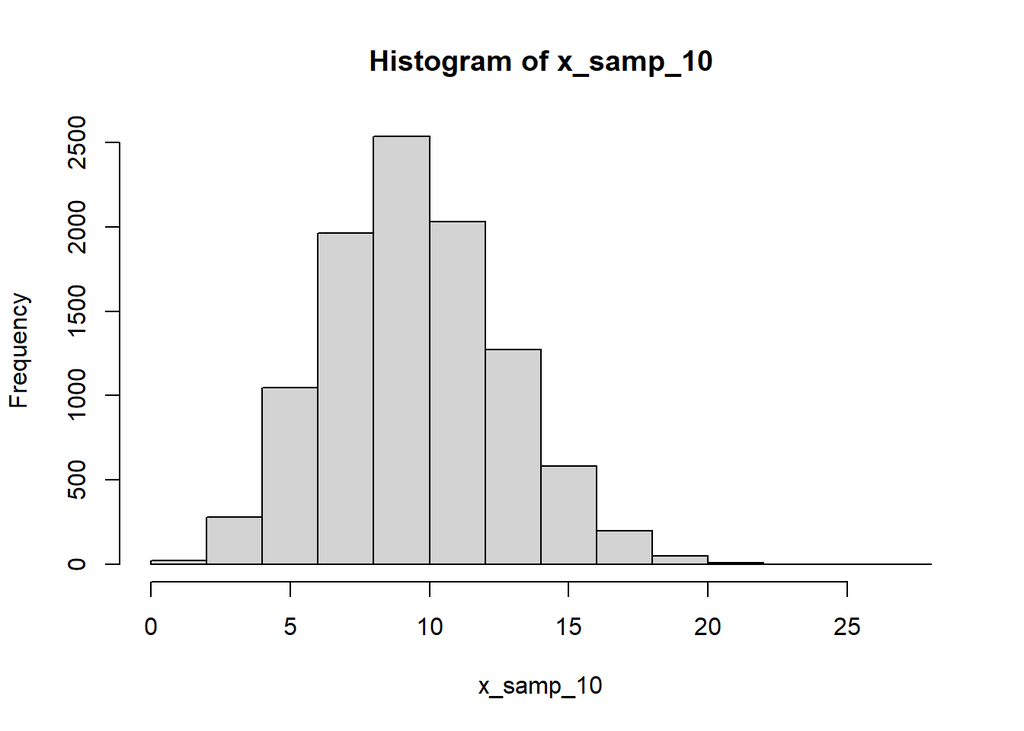

```r
x_samp_10 <- rpois(n, lambda = 10)
hist(x_samp_10)
```

```r
param_vect <- rep(c(1, 2, 3, 4, 5, 6), each = n)
samp_vect <- modify(.x = param_vect, .f = ~ rpois(n = 1, lambda = .x))
```

```r
samp_df <- tibble(param_val = param_vect,
                  sample_val = samp_vect)
```

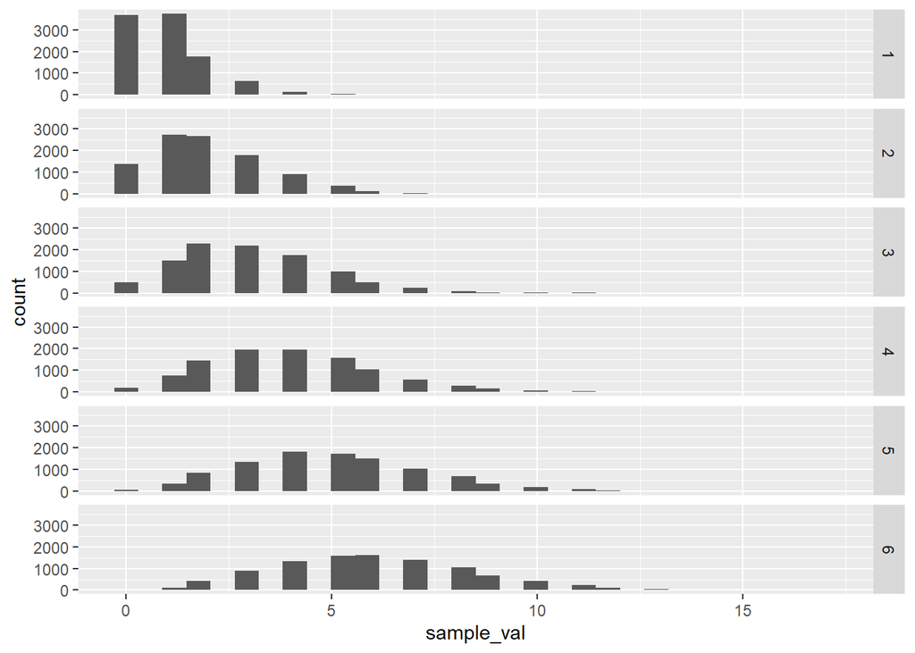

```r
samp_df %>%
  ggplot(aes(x = sample_val)) +
  geom_histogram() +
  facet_grid(param_val ~ .)
```